# C_5数据

```python
import os
import pandas as pd
import matplotlib.pyplot as plt
import seaborn as sns
from wordcloud import WordCloud
import warnings

sns.set_style('darkgrid')
warnings.filterwarnings('ignore')

plt.rcParams['font.sans-serif']=['SimHei']
plt.rcParams['axes.unicode_minus']=False
```

```python
item_df = pd.read_csv('New folder/C_5_u.item', encoding='iso-8859-1', sep='|', header=None)
user_df = pd.read_csv('New folder/C_5_u.user', encoding='iso-8859-1', sep='|', header=None)
base_df = pd.read_csv('New folder/C_5_u1.base', encoding='iso-8859-1', sep='\t', header=None)

item_col_name = '电影ID 电影名称 发布日期 视频发布日期 IMDb网址 未知 行动 冒险 动画 童装 喜剧 犯罪 纪录片 戏剧 幻想 黑色电影 恐怖 音乐剧 神秘 浪漫 科幻 惊悚 战争 西餐'.split(' ')
user_col_name = '用户名 年龄 性别 职业 邮政编码'.split(' ')
base_col_name = '用户名 商品编号 评级 时间戳'.split(' ')

item_df.columns = item_col_name
user_df.columns = user_col_name
base_df.columns = base_col_name
```

```python
item_df.head()
```

|  | 电影ID | 电影名称 | 发布日期 | 视频发布日期 | IMDb网址 | 未知 | 行动 | 冒险 | 动画 | 童装 | ... | 幻想 | 黑色电影 | 恐怖 | 音乐剧 | 神秘 | 浪漫 | 科幻 | 惊悚 | 战争 | 西餐 |
| --- | --- | --- | --- | --- | --- | --- | --- | --- | --- | --- | --- | --- | --- | --- | --- | --- | --- | --- | --- | --- | --- |
| 0 | 1 | Toy Story (1995) | 01-Jan-1995 | NaN | http://us.imdb.com/M/title-exact?Toy%20Story%2... | 0 | 0 | 0 | 1 | 1 | ... | 0 | 0 | 0 | 0 | 0 | 0 | 0 | 0 | 0 | 0 |
| 1 | 2 | GoldenEye (1995) | 01-Jan-1995 | NaN | http://us.imdb.com/M/title-exact?GoldenEye%20(... | 0 | 1 | 1 | 0 | 0 | ... | 0 | 0 | 0 | 0 | 0 | 0 | 0 | 1 | 0 | 0 |
| 2 | 3 | Four Rooms (1995) | 01-Jan-1995 | NaN | http://us.imdb.com/M/title-exact?Four%20Rooms%... | 0 | 0 | 0 | 0 | 0 | ... | 0 | 0 | 0 | 0 | 0 | 0 | 0 | 1 | 0 | 0 |
| 3 | 4 | Get Shorty (1995) | 01-Jan-1995 | NaN | http://us.imdb.com/M/title-exact?Get%20Shorty%... | 0 | 1 | 0 | 0 | 0 | ... | 0 | 0 | 0 | 0 | 0 | 0 | 0 | 0 | 0 | 0 |
| 4 | 5 | Copycat (1995) | 01-Jan-1995 | NaN | http://us.imdb.com/M/title-exact?Copycat%20(1995) | 0 | 0 | 0 | 0 | 0 | ... | 0 | 0 | 0 | 0 | 0 | 0 | 0 | 1 | 0 | 0 |

5 rows × 24 columns

```python
user_df.head()
```

|  | 用户名 | 年龄 | 性别 | 职业 | 邮政编码 |
| --- | --- | --- | --- | --- | --- |
| 0 | 1 | 24 | M | technician | 85711 |
| 1 | 2 | 53 | F | other | 94043 |
| 2 | 3 | 23 | M | writer | 32067 |
| 3 | 4 | 24 | M | technician | 43537 |
| 4 | 5 | 33 | F | other | 15213 |

```python
base_df.head()
```

|  | 用户名 | 商品编号 | 评级 | 时间戳 |
| --- | --- | --- | --- | --- |
| 0 | 1 | 1 | 5 | 874965758 |
| 1 | 1 | 2 | 3 | 876893171 |
| 2 | 1 | 3 | 4 | 878542960 |
| 3 | 1 | 4 | 3 | 876893119 |
| 4 | 1 | 5 | 3 | 889751712 |

根据文档C_5_README.md,我们读取了所有数据集，并根据用户id和电影id,将数据连接起来

```python
df = pd.merge(left=base_df, right=user_df, on='用户名', how='left')
df = pd.merge(left=df, right=item_df, left_on='商品编号', right_on='电影ID', how='left')
```

```python
df.head()
```

|  | 用户名 | 商品编号 | 评级 | 时间戳 | 年龄 | 性别 | 职业 | 邮政编码 | 电影ID | 电影名称 | ... | 幻想 | 黑色电影 | 恐怖 | 音乐剧 | 神秘 | 浪漫 | 科幻 | 惊悚 | 战争 | 西餐 |
| --- | --- | --- | --- | --- | --- | --- | --- | --- | --- | --- | --- | --- | --- | --- | --- | --- | --- | --- | --- | --- | --- |
| 0 | 1 | 1 | 5 | 874965758 | 24 | M | technician | 85711 | 1 | Toy Story (1995) | ... | 0 | 0 | 0 | 0 | 0 | 0 | 0 | 0 | 0 | 0 |
| 1 | 1 | 2 | 3 | 876893171 | 24 | M | technician | 85711 | 2 | GoldenEye (1995) | ... | 0 | 0 | 0 | 0 | 0 | 0 | 0 | 1 | 0 | 0 |
| 2 | 1 | 3 | 4 | 878542960 | 24 | M | technician | 85711 | 3 | Four Rooms (1995) | ... | 0 | 0 | 0 | 0 | 0 | 0 | 0 | 1 | 0 | 0 |
| 3 | 1 | 4 | 3 | 876893119 | 24 | M | technician | 85711 | 4 | Get Shorty (1995) | ... | 0 | 0 | 0 | 0 | 0 | 0 | 0 | 0 | 0 | 0 |
| 4 | 1 | 5 | 3 | 889751712 | 24 | M | technician | 85711 | 5 | Copycat (1995) | ... | 0 | 0 | 0 | 0 | 0 | 0 | 0 | 1 | 0 | 0 |

5 rows × 32 columns

### 标签分布

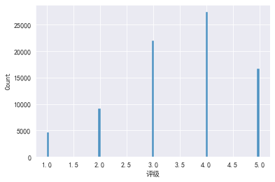

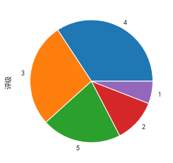

```python
plt.figure()
sns.histplot(df['评级'])
plt.figure()
df['评级'].value_counts().plot.pie()
```

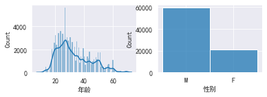

```python
plt.subplot(2, 2, 1)
sns.histplot(df['年龄'], kde=True)
plt.subplot(2, 2, 2)
sns.histplot(df['性别'])
```

```
(-0.5, 899.5, 599.5, -0.5)
```

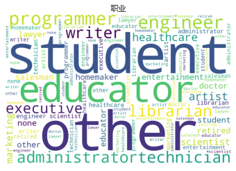

```python
wd = WordCloud(background_color="white",repeat=True,max_words=100, height=600,width=900, random_state=42)
wd.generate_from_frequencies(df['职业'].value_counts())
plt.imshow(wd)
plt.title('职业')
plt.axis('off')
```

## 数据清洗

该数据集比较容易清洗，我们的目标变量为评级，等级为1-5级

有用的特征为：年龄、性别、职业、发布日期、电影种类

可以看做是不同种类的用户对不同种类的电影的偏好

其中性别、职业属于分类变量，与电影种类一样进行One-Hot编码即可

```python
df = pd.get_dummies(df, columns=['性别', '职业'])
df.head()
```

|  | 用户名 | 商品编号 | 评级 | 时间戳 | 年龄 | 邮政编码 | 电影ID | 电影名称 | 发布日期 | 视频发布日期 | ... | 职业_marketing | 职业_none | 职业_other | 职业_programmer | 职业_retired | 职业_salesman | 职业_scientist | 职业_student | 职业_technician | 职业_writer |
| --- | --- | --- | --- | --- | --- | --- | --- | --- | --- | --- | --- | --- | --- | --- | --- | --- | --- | --- | --- | --- | --- |
| 0 | 1 | 1 | 5 | 874965758 | 24 | 85711 | 1 | Toy Story (1995) | 01-Jan-1995 | NaN | ... | 0 | 0 | 0 | 0 | 0 | 0 | 0 | 0 | 1 | 0 |
| 1 | 1 | 2 | 3 | 876893171 | 24 | 85711 | 2 | GoldenEye (1995) | 01-Jan-1995 | NaN | ... | 0 | 0 | 0 | 0 | 0 | 0 | 0 | 0 | 1 | 0 |
| 2 | 1 | 3 | 4 | 878542960 | 24 | 85711 | 3 | Four Rooms (1995) | 01-Jan-1995 | NaN | ... | 0 | 0 | 0 | 0 | 0 | 0 | 0 | 0 | 1 | 0 |
| 3 | 1 | 4 | 3 | 876893119 | 24 | 85711 | 4 | Get Shorty (1995) | 01-Jan-1995 | NaN | ... | 0 | 0 | 0 | 0 | 0 | 0 | 0 | 0 | 1 | 0 |
| 4 | 1 | 5 | 3 | 889751712 | 24 | 85711 | 5 | Copycat (1995) | 01-Jan-1995 | NaN | ... | 0 | 0 | 0 | 0 | 0 | 0 | 0 | 0 | 1 | 0 |

5 rows × 53 columns

```python
use_cols = ['评级', '年龄', '未知', '行动', '冒险', '动画', '童装', '喜剧', '犯罪', '纪录片',
       '戏剧', '幻想', '黑色电影', '恐怖', '音乐剧', '神秘', '浪漫', '科幻', '惊悚', '战争', '西餐',
       '性别_F', '性别_M', '职业_administrator', '职业_artist', '职业_doctor',
       '职业_educator', '职业_engineer', '职业_entertainment', '职业_executive',
       '职业_healthcare', '职业_homemaker', '职业_lawyer', '职业_librarian',
       '职业_marketing', '职业_none', '职业_other', '职业_programmer', '职业_retired',
       '职业_salesman', '职业_scientist', '职业_student', '职业_technician',
       '职业_writer']

data = df[use_cols]
```

```python
data.head()
```

|  | 评级 | 年龄 | 未知 | 行动 | 冒险 | 动画 | 童装 | 喜剧 | 犯罪 | 纪录片 | ... | 职业_marketing | 职业_none | 职业_other | 职业_programmer | 职业_retired | 职业_salesman | 职业_scientist | 职业_student | 职业_technician | 职业_writer |
| --- | --- | --- | --- | --- | --- | --- | --- | --- | --- | --- | --- | --- | --- | --- | --- | --- | --- | --- | --- | --- | --- |
| 0 | 5 | 24 | 0 | 0 | 0 | 1 | 1 | 1 | 0 | 0 | ... | 0 | 0 | 0 | 0 | 0 | 0 | 0 | 0 | 1 | 0 |
| 1 | 3 | 24 | 0 | 1 | 1 | 0 | 0 | 0 | 0 | 0 | ... | 0 | 0 | 0 | 0 | 0 | 0 | 0 | 0 | 1 | 0 |
| 2 | 4 | 24 | 0 | 0 | 0 | 0 | 0 | 0 | 0 | 0 | ... | 0 | 0 | 0 | 0 | 0 | 0 | 0 | 0 | 1 | 0 |
| 3 | 3 | 24 | 0 | 1 | 0 | 0 | 0 | 1 | 0 | 0 | ... | 0 | 0 | 0 | 0 | 0 | 0 | 0 | 0 | 1 | 0 |
| 4 | 3 | 24 | 0 | 0 | 0 | 0 | 0 | 0 | 1 | 0 | ... | 0 | 0 | 0 | 0 | 0 | 0 | 0 | 0 | 1 | 0 |

5 rows × 44 columns

## 建立模型

```python
from sklearn.ensemble import RandomForestClassifier, GradientBoostingClassifier, BaggingClassifier
from sklearn.metrics import classification_report
from sklearn.neural_network import MLPClassifier
from sklearn.linear_model import LogisticRegression
```

### 随机森林

```python
x = data.drop(columns=['评级'])
y = data['评级']

rf_model = RandomForestClassifier(n_estimators=100)
rf_model.fit(x, y)
y_pred = rf_model.predict(x)
print(classification_report(y, y_pred))
```

```
              precision    recall  f1-score   support

           1       0.71      0.47      0.56      4719
           2       0.67      0.40      0.50      9178
           3       0.60      0.62      0.61     21963
           4       0.59      0.73      0.65     27396
           5       0.65      0.58      0.61     16744

    accuracy                           0.62     80000
   macro avg       0.65      0.56      0.59     80000
weighted avg       0.62      0.62      0.61     80000
```

### 多标签分类神经网络

```python
x = data.drop(columns=['评级'])
y = data['评级']

model = MLPClassifier()
model.fit(x, y)
y_pred = model.predict(x)
print(classification_report(y, y_pred))
```

```
              precision    recall  f1-score   support

           1       0.50      0.14      0.22      4719
           2       0.33      0.01      0.02      9178
           3       0.36      0.36      0.36     21963
           4       0.39      0.67      0.49     27396
           5       0.42      0.23      0.30     16744

    accuracy                           0.38     80000
   macro avg       0.40      0.28      0.28     80000
weighted avg       0.39      0.38      0.34     80000
```

### 梯度提升树

```python
x = data.drop(columns=['评级'])
y = data['评级']

model = GradientBoostingClassifier()
model.fit(x, y)
y_pred = model.predict(x)
print(classification_report(y, y_pred))
```

```
              precision    recall  f1-score   support

           1       0.61      0.11      0.18      4719
           2       0.65      0.00      0.00      9178
           3       0.38      0.21      0.27     21963
           4       0.36      0.84      0.51     27396
           5       0.47      0.10      0.16     16744

    accuracy                           0.37     80000
   macro avg       0.49      0.25      0.23     80000
weighted avg       0.44      0.37      0.29     80000
```

## 文字性结论

```python
feature_importance = pd.DataFrame({'name': x.columns, 'importance': rf_model.feature_importances_})
```

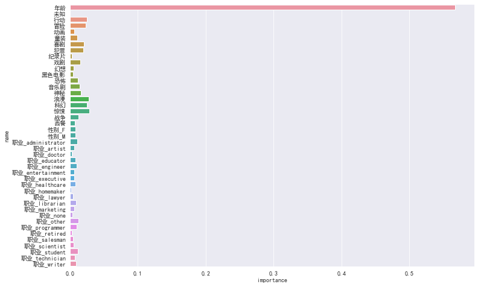

```python
plt.figure(figsize=(12, 8))
sns.barplot(y='name', x='importance', data=feature_importance)
```

可以看出，年龄是影响评分的重要因素

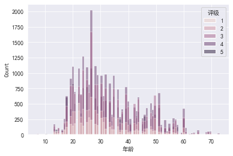

```python
tmp_df = data[['评级', '年龄']].copy()

tmp_df['年龄分层'] = pd.cut(tmp_df['年龄'], bins=[0, 24, 40, 56, 72])
sns.histplot(data=tmp_df, x='年龄', hue='评级')
```

由于年龄的特征过强，我们无法直观看出除年龄外其他特征带来的影响，因此我们去除年龄之后再观察特征重要性，可以发现

1. 电影类型未知时不能带来有用的信息，而电影类型为行动、冒险、浪漫、科幻、惊悚比较影响电影评级，说明不同年龄段的人群对这些类型的电影评价差异较大
2. 性别不作为影响评分的主要因素，可以看出男性和女性在对电影评级时差异较为细微
3. 不同职业会对电影评级造成差异不等的影响，职业为学生或其他（未明确职业）的人群对电影评级差异较大

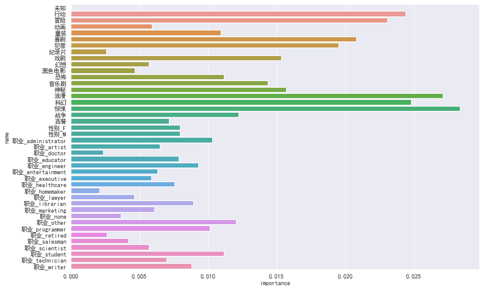

```python
plt.figure(figsize=(12, 8))
sns.barplot(y='name', x='importance', data=feature_importance.iloc[1:, :])
```